# Du thé : exemple d'analyse de données

Bro Frédéric - PFC - Liban - 20 janvier 2020

Présentation :

Une étude a été menée auprès de 300 consommateurs de thé.  
Les résultats sont enregistrés dans le fichier `'the.csv'`.

Objectifs :

- faire du data mining : fouilles de données
- donner un exemple fondamental : étude d'une enquête

Table des matières :

1 - Lecture et traitement des données avec Pandas

2 - Sélectionner des données

3 - Croiser des données

4 - Regrouper des données

> Lecture et traitement des données avec Pandas

Retour table des matières

```python
import pylab as pl
import pandas as pa

pl.style.use('bmh')
```

```python
T = pa.read_csv('the.csv')
T.head()
```

|  | tout_moment | variete | comment | sucre | forme | type | sexe | CSP | sportif | age | frequence | plus_pour_la_sante |
| --- | --- | --- | --- | --- | --- | --- | --- | --- | --- | --- | --- | --- |
| 0 | 0 | noir | pur | 1 | sachet | inconnu | H | cadre moyen | 1 | 39 | 1/jour | 1 |
| 1 | 0 | noir | lait | 0 | sachet | variable | F | cadre moyen | 1 | 45 | 1/jour | 1 |
| 2 | 0 | parfumé | pur | 0 | sachet | variable | F | autre actif | 1 | 47 | + de 2/jour | 1 |
| 3 | 0 | parfumé | pur | 1 | sachet | variable | H | étudiant | 0 | 23 | 1/jour | 1 |
| 4 | 1 | parfumé | pur | 0 | sachet | variable | H | employé | 1 | 48 | + de 2/jour | 0 |

> Sélectionner des données

Retour table des matières

- Sélectionnons les femmes de plus de 30 ans et créons la table `T1` :

```python
T1 = T.query('sexe == "F" and age >= 30')
T1.head()
```

|  | tout_moment | variete | comment | sucre | forme | type | sexe | CSP | sportif | age | frequence | plus_pour_la_sante |
| --- | --- | --- | --- | --- | --- | --- | --- | --- | --- | --- | --- | --- |
| 1 | 0 | noir | lait | 0 | sachet | variable | F | cadre moyen | 1 | 45 | 1/jour | 1 |
| 2 | 0 | parfumé | pur | 0 | sachet | variable | F | autre actif | 1 | 47 | + de 2/jour | 1 |
| 7 | 0 | noir | lait | 0 | sachet | variable | F | cadre moyen | 1 | 36 | 1 à 2/sem | 1 |
| 17 | 0 | parfumé | pur | 0 | sachet | variable | F | non actif | 1 | 72 | + de 2/jour | 1 |
| 18 | 0 | noir | pur | 0 | sachet | marque_connue | F | non actif | 0 | 73 | + de 2/jour | 0 |

- Sélectionnons les sportifs ou les moins de 25 ans et créons la table `T2` :

```python
T2 = T.query('sportif == 1 or age <= 25')
T2.head()
```

|  | tout_moment | variete | comment | sucre | forme | type | sexe | CSP | sportif | age | frequence | plus_pour_la_sante |
| --- | --- | --- | --- | --- | --- | --- | --- | --- | --- | --- | --- | --- |
| 0 | 0 | noir | pur | 1 | sachet | inconnu | H | cadre moyen | 1 | 39 | 1/jour | 1 |
| 1 | 0 | noir | lait | 0 | sachet | variable | F | cadre moyen | 1 | 45 | 1/jour | 1 |
| 2 | 0 | parfumé | pur | 0 | sachet | variable | F | autre actif | 1 | 47 | + de 2/jour | 1 |
| 3 | 0 | parfumé | pur | 1 | sachet | variable | H | étudiant | 0 | 23 | 1/jour | 1 |
| 4 | 1 | parfumé | pur | 0 | sachet | variable | H | employé | 1 | 48 | + de 2/jour | 0 |

> Croiser des données

Retour table des matières

- Croisons les variables statistiques `sexe` avec `comment` :

```python
E = pa.crosstab(T['sexe'],T['comment'])
E
```

| comment sexe | autre | citron | lait | pur |
| --- | --- | --- | --- | --- |
| F | 6 | 19 | 32 | 121 |
| H | 3 | 14 | 31 | 74 |

- Trabsposons la table `E` :

```python
E.T
```

| sexe comment | F | H |
| --- | --- | --- |
| autre | 6 | 3 |
| citron | 19 | 14 |
| lait | 32 | 31 |
| pur | 121 | 74 |

- Table croisée marginale des effectifs de `sexe` avec `comment` :

```python
M = pa.crosstab(T['sexe'],T['comment'],
                margins=True)
M
```

| comment sexe | autre | citron | lait | pur | All |
| --- | --- | --- | --- | --- | --- |
| F | 6 | 19 | 32 | 121 | 178 |
| H | 3 | 14 | 31 | 74 | 122 |
| All | 9 | 33 | 63 | 195 | 300 |

On note :

> - $F$ : l'ensemble des femmes
> - $C$ : l'ensemble des buveurs de thé avec du Citron
> - $L$ : l'ensemble des buveurs de thé avec du Lait
- Fréquences conditionnelles :

```python
Freq = M['lait']/M['All']
Freq
```

```
sexe
F      0.179775
H      0.254098
All    0.210000
dtype: float64
```

Traductions :

> - $f_F(L)\approx18\%$
> - $f_H(L)\approx25\%$
- Visualation des fréquences conditionnelles :

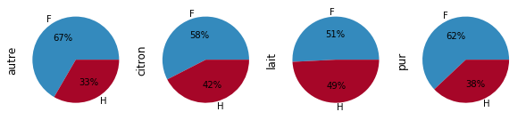

```python
E.plot.pie(subplots=True,legend=None,autopct='%.0f%%',
          figsize=(10,3))
pl.show()
```

**Remarque :** on peut mettre aussi `autopct=lambda x : '{:.0f}%'.format(x)`

```python
E.T
```

| sexe comment | F | H |
| --- | --- | --- |
| autre | 6 | 3 |
| citron | 19 | 14 |
| lait | 32 | 31 |
| pur | 121 | 74 |

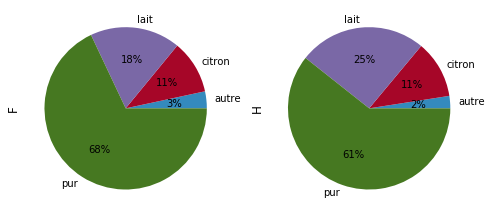

```python
E.T.plot.pie(subplots=True,legend=None,autopct='%.0f%%',
          figsize=(8,4))
pl.show()
```

> Regrouper des données

Retour table des matières

On note :

> - $F$ : l'ensemble des femmes
> - $P$ : l'ensemble des personnes qui pensent que boire du thé est un plus pour la santé
- Regroupons les données selon la variable `sexe` :

```python
T.groupby('sexe').mean()
```

| sexe | tout_moment | sucre | sportif | age | plus_pour_la_sante |
| --- | --- | --- | --- | --- | --- |
| F | 0.353933 | 0.398876 | 0.544944 | 37.353933 | 0.713483 |
| H | 0.327869 | 0.606557 | 0.672131 | 36.614754 | 0.680328 |

Traductions :

> - L'âge moyen des femmes est de 37 ans contre 36 ans pour les hommes.
> - $f_F(P)\approx71\%$
> - $f_H(P)\approx68\%$
- Regroupons les données selon les variables `sexe` et `sucre` :

```python
T.groupby(['sexe','sucre']).mean()
```

| sexe | sucre | tout_moment | sportif | age | plus_pour_la_sante |
| --- | --- | --- | --- | --- | --- |
| F | 0 | 0.336449 | 0.551402 | 40.757009 | 0.757009 |
|  | 1 | 0.380282 | 0.535211 | 32.225352 | 0.647887 |
| H | 0 | 0.312500 | 0.645833 | 41.145833 | 0.687500 |
|  | 1 | 0.337838 | 0.689189 | 33.675676 | 0.675676 |

Traductions :

> - Ce sont les plus jeunes qui sucrent leur thé.
> - $f_{F\cap \overline{S}}(P)\approx76\%$
> - $f_{F\cap S}(P)\approx65\%$

Fini ...

Retour au début

```python
from IPython.core.display import HTML
htm = open("style_css.txt").read()
HTML(htm)
```